# Distracted Driver Detection

## Problem Description :

Driving a car is a complex task, and it requires complete attention. Distracted driving is any activity that takes away the driver’s attention from the road. The National Highway Traffic Safety Administration (NHTSA) reported that 36,750 people died in motor vehicle crashes in 2018, and 12% of it was due to distracted driving.

Many States now have laws against texting, talking on a cell phone, and other distractions while driving. We believe that computer vision can augment the efforts by the governments to prevent accidents caused by distracted driving. Our algorithm automatically detects the distracted activity of the drivers and alerts them. We envision this type of product being embedded in cars to help drivers avoid distraction.

There are 2 classes including safe driving in the dataset:

```
c0 Safe driving.
c1 Texting (right hand).
```

## Importing required Packages

```python
# Importing Packages
import os
import tensorflow
import pandas as pd
import numpy as np
import seaborn as sns
import matplotlib.pyplot as plt
import pandas.util.testing as tm
import matplotlib
#checking versions of packages
print(tensorflow.__version__)
print(pd.__version__)
print(np.__version__)
print(sns.__version__)
print(matplotlib.__version__)
%matplotlib inline
```

```
2.2.0
1.0.5
1.18.5
0.10.1
3.2.2
```

## Importing the dataset

```python
# Changing directory location to data set folder
os.chdir('/content/drive/My Drive/2020/Courses Taken/Data science/Project/')
%pwd
```

```
'/content/drive/My Drive/2020/Courses Taken/Data science/Project'
```

```python
# displaying folder names in the data set
print("Folders in data set : ",os.listdir("/content/drive/My Drive/2020/Courses Taken/Data science/Project/Dataset2/imgs"))
```

```
Folders in data set :  ['img_772.jpg', 'img_2663.jpg', 'validation', 'train', 'img_3432.jpg']
```

```python
#printing folders in training data
print(os.listdir('/content/drive/My Drive/2020/Courses Taken/Data science/Project/Dataset2/imgs/train'))
```

```
['c1', 'c0']
```

```python
# printing no of files in each folder of train
for k in os.listdir('/content/drive/My Drive/2020/Courses Taken/Data science/Project/Dataset2/imgs/train'):
    num_files = len(os.listdir('/content/drive/My Drive/2020/Courses Taken/Data science/Project/Dataset2/imgs/train/'+k))
    print("{} : {}".format(k, num_files))
```

```
c1 : 1617
c0 : 1789
```

```python
# printing no of files in each folder of validation
for k in os.listdir('/content/drive/My Drive/2020/Courses Taken/Data science/Project/Dataset2/imgs/validation'):
    num_files = len(os.listdir('/content/drive/My Drive/2020/Courses Taken/Data science/Project/Dataset2/imgs/validation/'+k))
    print("{} : {}".format(k, num_files))
```

```
c0 : 700
c1 : 650
```

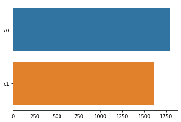

```python
#visualizing counts of features
length0 = len(os.listdir('/content/drive/My Drive/2020/Courses Taken/Data science/Project/Dataset2/imgs/train/c0'))
length1 = len(os.listdir('/content/drive/My Drive/2020/Courses Taken/Data science/Project/Dataset2/imgs/train/c1'))
sns.barplot([length0,length1],['c0','c1'])
```

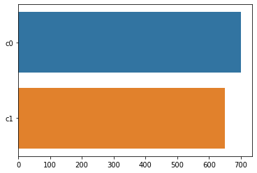

```python
#visualizing counts of features
length2 = len(os.listdir('/content/drive/My Drive/2020/Courses Taken/Data science/Project/Dataset2/imgs/validation/c0'))
length3 = len(os.listdir('/content/drive/My Drive/2020/Courses Taken/Data science/Project/Dataset2/imgs/validation/c1'))
sns.barplot([length2,length3],['c0','c1'])
```

```python
#storing base directory in a variable and assigning the train and validation data to variables
base_dir = '/content/drive/My Drive/2020/Courses Taken/Data science/Project/Dataset2/imgs'
train_dir = os.path.join(base_dir,'train')
validation_dir = os.path.join(base_dir,'validation')
## Directory with training each cotegory of c0 and c1 pictures
train_0_dir = os.path.join(train_dir,'c0')
train_1_dir = os.path.join(train_dir,'c1')
validation_0_dir = os.path.join(validation_dir,'c0')
validation_1_dir = os.path.join(validation_dir,'c1')
```

```python
#displaying the image labels of train
train_0_filenames = os.listdir(train_0_dir)
train_0_filenames[:4]
```

```
['img_80294.jpg', 'img_70406.jpg', 'img_67865.jpg', 'img_82321.jpg']
```

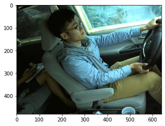

```python
#reading and displaying an image from c0 feature
plt.imshow(plt.imread(train_0_dir+'/img_70406.jpg'))
```

```python
#displaying the image labels of train data
train_1_filenames = os.listdir(train_1_dir)
train_1_filenames[:4]
```

```
['img_70214.jpg', 'img_4902.jpg', 'img_65009.jpg', 'img_52146.jpg']
```

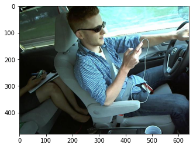

```python
#reading and displaying an image from c1 feature
plt.imshow(plt.imread(train_1_dir+'/img_4902.jpg'))
```

```python
from tensorflow.keras.preprocessing.image import ImageDataGenerator

# All images will be rescaled by 1./255
train_datagen = ImageDataGenerator(rescale=1./255)
val_datagen = ImageDataGenerator(rescale=1./255)

# Flow training images in batches of 20 using train_datagen generator
train_generator = train_datagen.flow_from_directory(
        train_dir,  # This is the source directory for training images
        target_size=(150, 150),  # All images will be resized to 150x150
        batch_size=20, # 2000/20 --> 100
        # Since we use binary_crossentropy loss, we need binary labels
        class_mode='binary')

# Flow validation images in batches of 20 using val_datagen generator
validation_generator = val_datagen.flow_from_directory(
        validation_dir,
        target_size=(150, 150),
        batch_size=20,
        class_mode='binary')
```

```
Found 3406 images belonging to 2 classes.
Found 1350 images belonging to 2 classes.
```

```python
train_generator
```

```
<keras_preprocessing.image.directory_iterator.DirectoryIterator at 0x7fb50110ecc0>
```

```
(20, 150, 150, 3)
(20,)
```

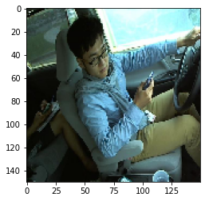

```python
imgs,labels = train_generator.next()
print(imgs.shape)
print(labels.shape)
plt.imshow(imgs[0,:,:,:])
```

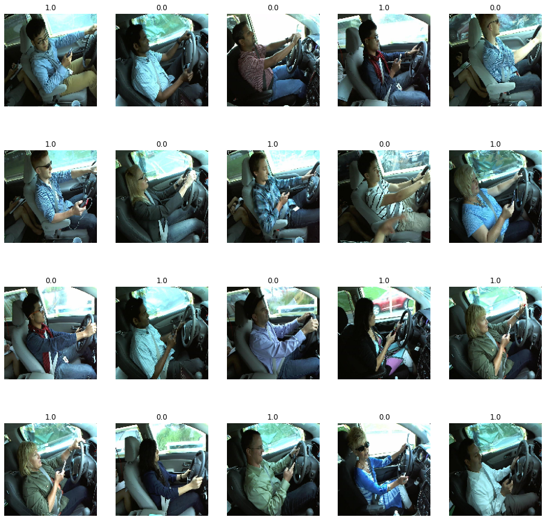

```python
plt.figure(figsize=(16,16))
pos = 1  ## plot position
for i in range(20):
  plt.subplot(4,5,pos)
  plt.imshow(imgs[i,:,:,:]) # To display the image
  plt.title(labels[i])
  plt.axis('off')
  pos += 1
```

```python
## import required methods
from tensorflow.keras.models import Sequential
from tensorflow.keras.layers import Conv2D,Dense,Flatten,MaxPooling2D
```

```python
model = Sequential()
## add a conv layer folloed by maxpooling
model.add(Conv2D(16,3,activation='relu',input_shape=(150,150,3)))
model.add(MaxPooling2D(2))
## add a conv layer folloed by maxpooling
model.add(Conv2D(32,3,activation='relu'))
model.add(MaxPooling2D(2))
## add a conv layer folloed by maxpooling
model.add(Conv2D(64,3,activation='relu'))
model.add(MaxPooling2D(2))
# Convert the faeturemap into 1D array
model.add(Flatten())
# Fully connected layer with 512 neurons
model.add(Dense(512,activation='relu'))
## Final output layer
model.add(Dense(1,activation='sigmoid'))
## let us see the the summary
model.summary()
```

```
Model: "sequential_5"
_________________________________________________________________
Layer (type)                 Output Shape              Param #
=================================================================
conv2d_15 (Conv2D)           (None, 148, 148, 16)      448
_________________________________________________________________
max_pooling2d_15 (MaxPooling (None, 74, 74, 16)        0
_________________________________________________________________
conv2d_16 (Conv2D)           (None, 72, 72, 32)        4640
_________________________________________________________________
max_pooling2d_16 (MaxPooling (None, 36, 36, 32)        0
_________________________________________________________________
conv2d_17 (Conv2D)           (None, 34, 34, 64)        18496
_________________________________________________________________
max_pooling2d_17 (MaxPooling (None, 17, 17, 64)        0
_________________________________________________________________
flatten_5 (Flatten)          (None, 18496)             0
_________________________________________________________________
dense_10 (Dense)             (None, 512)               9470464
_________________________________________________________________
dense_11 (Dense)             (None, 1)                 513
=================================================================
Total params: 9,494,561
Trainable params: 9,494,561
Non-trainable params: 0
_________________________________________________________________
```

```python
### Compiling the modle
import tensorflow as tf
model.compile(loss=tf.keras.losses.BinaryCrossentropy(),metrics=['accuracy'])
```

```python
history = model.fit(train_generator,epochs=15,validation_data=validation_generator,batch_size=32)
```

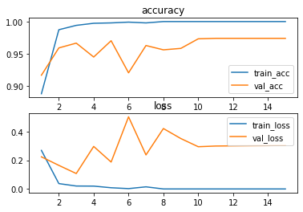

```python
train_acc = history.history['accuracy']
val_acc = history.history['val_accuracy']
train_loss = history.history['loss']
val_loss = history.history['val_loss']
epochs = list(range(1,16))
plt.subplot(2,1,1)
plt.plot(epochs,train_acc,label='train_acc')
plt.plot(epochs,val_acc,label='val_acc')
plt.title('accuracy')
plt.legend()
plt.subplot(2,1,2)
plt.plot(epochs,train_loss,label='train_loss')
plt.plot(epochs,val_loss,label='val_loss')
plt.title('loss')
plt.legend()
```

## Here we got training accuracy with 100% and validation accuracy with 97%

## The above plots describe about train accuracy and validation accuraycy with their respective loss

## Testing with unseen data

```
<class 'PIL.JpegImagePlugin.JpegImageFile'>
(355, 474, 3)
<class 'numpy.ndarray'>
(150, 150, 3)
(1, 150, 150, 3)
```

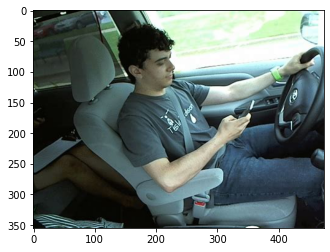

```python
from tensorflow.keras.preprocessing import image
import numpy as np
img = image.load_img('/content/drive/My Drive/2020/Courses Taken/Data science/Project/external-content.duckduckgo.com.jpeg')
print(type(img))
plt.imshow(plt.imread('/content/drive/My Drive/2020/Courses Taken/Data science/Project/external-content.duckduckgo.com.jpeg'))
img = tf.keras.preprocessing.image.img_to_array(img)
print(img.shape)
print(type(img))
img = tf.image.resize(img,(150,150))
## Scaling
img = img/255
print(img.shape)
img = np.expand_dims(img,axis=0)
print(img.shape)
```

```python
print(model.predict(img))
```

[output not shown]

```
<class 'PIL.JpegImagePlugin.JpegImageFile'>
(480, 640, 3)
<class 'numpy.ndarray'>
(150, 150, 3)
(1, 150, 150, 3)
```

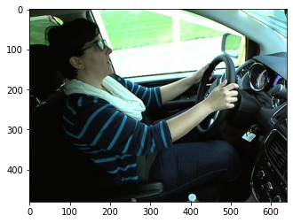

```python
img = image.load_img('/content/drive/My Drive/2020/Courses Taken/Data science/Project/Dataset2/imgs/img_772.jpg')
print(type(img))
plt.imshow(plt.imread('/content/drive/My Drive/2020/Courses Taken/Data science/Project/Dataset2/imgs/img_772.jpg'))
img = tf.keras.preprocessing.image.img_to_array(img)
print(img.shape)
print(type(img))
img = tf.image.resize(img,(150,150))
## Scaling
img = img/255
print(img.shape)
img = np.expand_dims(img,axis=0)
print(img.shape)
```

```python
print(model.predict(img))
```

```
[[7.9449724e-32]]
```

# Conclusion

By passing the unseen data into my model i can conclude that through CNN model my model is a working model with Accuracy 100% for training and 97% for testing.